# JSC370 Midterm

Kevin W

# Introduction

Transportation is the life-blood of civilization. For many people, the two largest purchases in their lives will be a house and a car. However, not all cars are built equally and, from personal experience, many car salesmen will not eagerly disclose these inequalities. Thus, I will be investigating the used car market for my project, thinking from the perspective of a prospective buyer and from a used car dealership.

The main question is as follows:

**What is the relationship between mileage, year, wheel configuration, body type, predicted market value(2023), and car listing prices on Kijiji(2019)?**

Specifically, from a dealership’s perspective, I want to analyze the depreciation of car prices with time and other factors, as well as find and evaluate many aspects that are associated with a car’s price.

My hypothesis is that the price of most cars decay exponentially at an annual rate, that is related to factors such as the price range of the car(ie. luxury vehicles may decay at different rates compared to other vehicles).

Decay in price, mileage and time may be highly correlated, and other factors such as wheel configuration and body type may affect both the listing price of a car, and the decay rate.

# Methods

The car listings dataset was sourced from [this github page](https://github.com/Pyligent/Car_ETL_PROJECT), and contains information for around 1000 unique Kijiji listings in the Greater Toronto Area. The data was acquired in 2019 through web scraping.

Using the `brand`, `model` and `model year` attributes from the car listings dataset, I attempted to scrape the market price for each car from MotorTrend.com, to augment the data. MotorTrend.com gives a “clean retail price” or “market price” for many cars, representing a “reasonable asking price” for cars with clean history, and no defects/damage.

Note that the market price was obtained in 2023, and may be lower than the listing prices obtained in 2019 due to depreciation. However, with prior knowledge that the depreciation rate should be fixed for different categories of cars and can be adjusted for, I believe relationships between these variables are still worth investigating.

### Data exploration

I used summary tables to explore each variable, to find and remove nonsensical or missing values. I used plotting and linear regression to further explore distributions of individual variables, and to explore relationships in the data.

### Data Wrangling

I removed columns that I’m not investigating, such as links and vehicle identification numbers, and converted the remaining columns to the correct data types. Cross-referencing with other sites, I believe MotorTrend market prices are given in CAD, so I did not perform any currency conversion.

I then removed listings with a listing price of 0. Kijiji sellers will often list a price of 0 or ‘Please Contact’ to attract buyers, which does not reflect the actual asking price.

Since market prices are scraped in 2023 and the dataset is from 2019, there is no reasonable way to impute the missing values in that column. Market price is an important variable in this investigation, so I decided to remove all rows with missing market prices.

I then mapped blank values of wheel and transmission configuration to “Other,” because I did not want to remove missing values. “Other” is already an existing category in the data, so I decided to cast all unknown values to that.

I also created a new `price range` variable that indicates if the market price of a car which had a market price below the 25th percentile, between the 25-75th percentile or above the 75th percentile, comparing to other recorded listings **in the same year**. This variable is intended to roughly indicate whether a vehicle is a “luxury vehicle” or not, and takes the values ‘low,’ ‘medium,’ and ‘high.’

The variables in the cleaned dataset are:

- Brand(eg. Honda)
- Model(eg. Civic)
- Model year(eg. 2001)
- Listing price(CAD)
- Mileage(Miles)
- Body type(eg. convertible, coupe, etc.)
- Wheel configuration(AWD, FWD, RWD, other)
- Market price(from MotorTrend.com, in CAD)
- Price range(low, medium, high, discussed earlier)

I performed further checks for anomalies and nonsensical values, but found nothing.

Here are some example rows from the raw data:

| brand | model | model_year | list_price | mileage | body_type | wheel_config | Market.Price.CAD | price_range |
| --- | --- | --- | --- | --- | --- | --- | --- | --- |
| Chevrolet | Corvette | 2019 | 110315 | 0 | Coupe (2 door) | RWD | 46779 | high |
| Chevrolet | Corvette | 2019 | 98095 | 0 | Coupe (2 door) | RWD | 46779 | high |
| Ram | 3500 | 2018 | 69198 | 8 | Pickup Truck | Other | 39499 | high |
| Mercedes-Benz | S-Class | 2016 | 66988 | 24944 | Sedan | 4x4 | 37030 | high |
| Cadillac | Escalade | 2017 | 83997 | 7273 | SUV, Crossover | 4x4 | 36952 | high |
| Cadillac | Escalade | 2017 | 72800 | 48625 | SUV, Crossover | Other | 36952 | high |

# Preliminary Results

## Univariate summaries

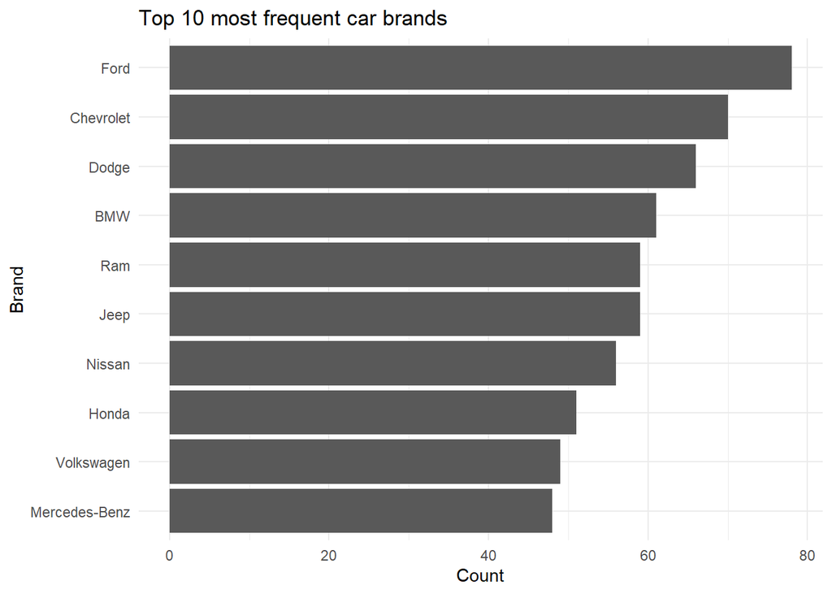

Here are some of the most frequent brands, most of which are well known. We see that many of the top brands manufacture trucks and other large vehicles, such as Ford, Chevrolet, Dodge and Ram.

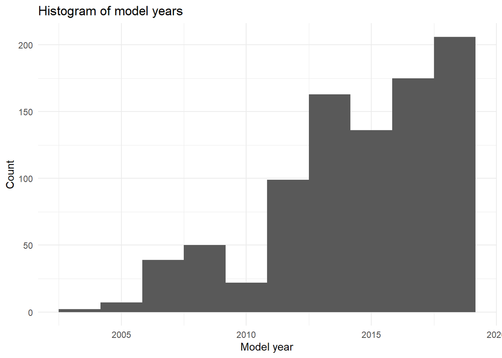

We see that most listings are for cars from recent years, with a large number between 2015 and 2019.

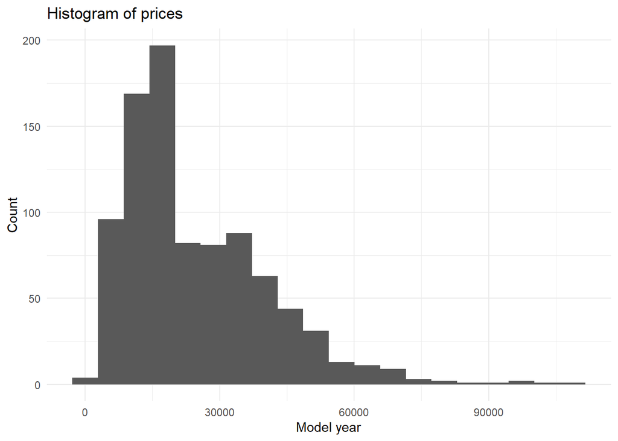

We see most cars are listed in the 0-30000CAD range, although some listings have prices higher than 100kCAD. This is consistent with the fact that most of the listings are for used cars, although some of the listings may be for luxury vehicles that cost significantly more than other cars.

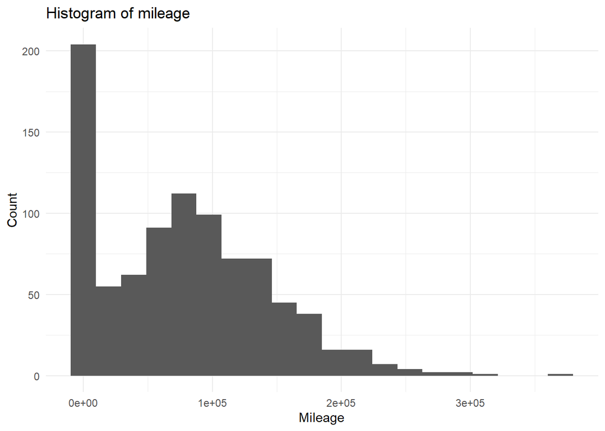

We see that many of the predictors, and the response are skewed, so we must keep that in mind when fitting and assessing models.

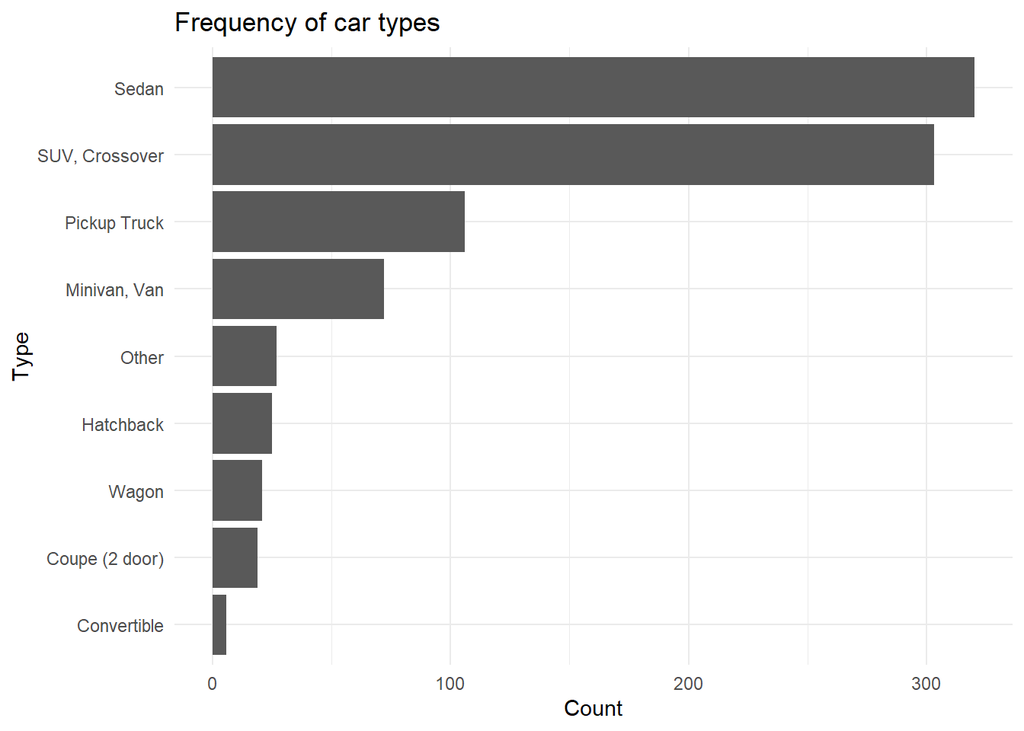

We see that the most common types or cars are sedans and SUV/crossover(a car that blends characteristics between other cars and an SUV). This is important to note when forming conclusions in the later sections, because sedans and SUVs naturally have different price points due to their size.

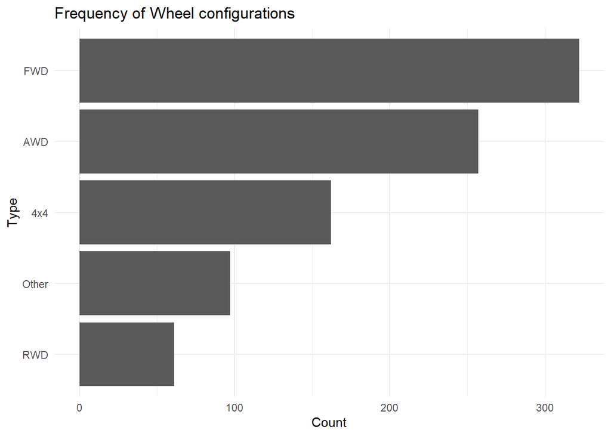

Note that the two most common wheel configurations are FWD and AWD, common in sedans and SUV/trucks. This suggests that the body type and wheel configuration of a car may be correlated, and is important to keep in mind.

I did not explore the distribution of market price because it is similar to listing price, which is evident in the bivariate plots.

### More summary statistics

| Variable | Mean | Median | SD |
| --- | --- | --- | --- |
| Listing Price(CAD) | 24735.78 | 19749 | 16153.353 |
| Market Price(CAD) | 13847.93 | 12680 | 6763.669 |
| Mileage(Mi) | 77792.47 | 74483 | 63797.968 |

## Analysis results

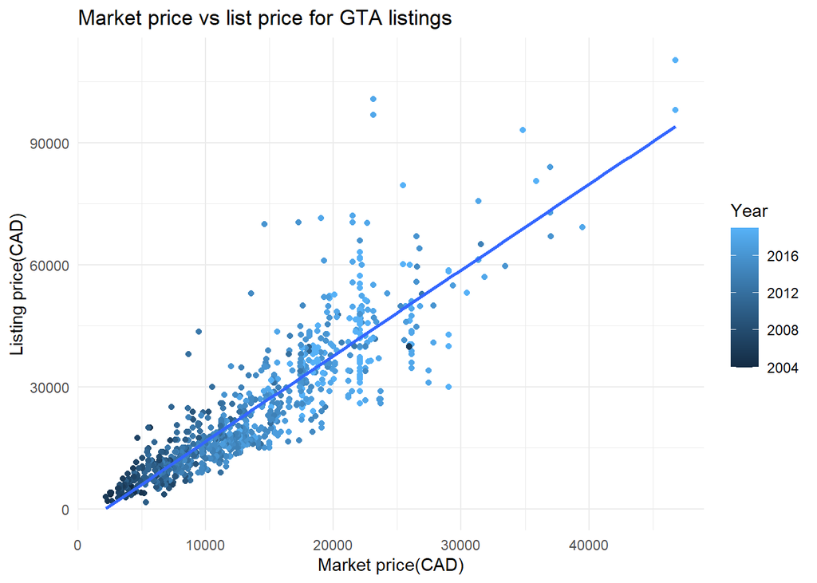

Linear regression estimates are given below:

| Estimate | Value |
| --- | --- |
| Intercept | -4403.9374377 |
| Slope | 2.104266 |

This suggests in the last 4 years, used car prices have decayed by around 50%, on average.

The scatterplot suggests a strong linear association between market price and listing prices, and the fitted regression supports the hypothesis that all of the cars have a similar depreciation rate, allowing us to adjust for it quite easily.

The scatter of points is cone shaped. This may be because different makes and models have different depreciation rates. In addition, it may be because factors that affect the price such as damages and car history, or even perceived value, is usually proportional to the price of the car(eg. damages on an expensive car will lower its perceived value more on a cheaper car).

Finally, we see that cars with higher prices are typically from more recent years. This suggests a relationship between year and “value” of a vehicle, supporting the idea that vehicle prices depreciate over time. However, further analysis must be done to infer the nature of the depreciation.

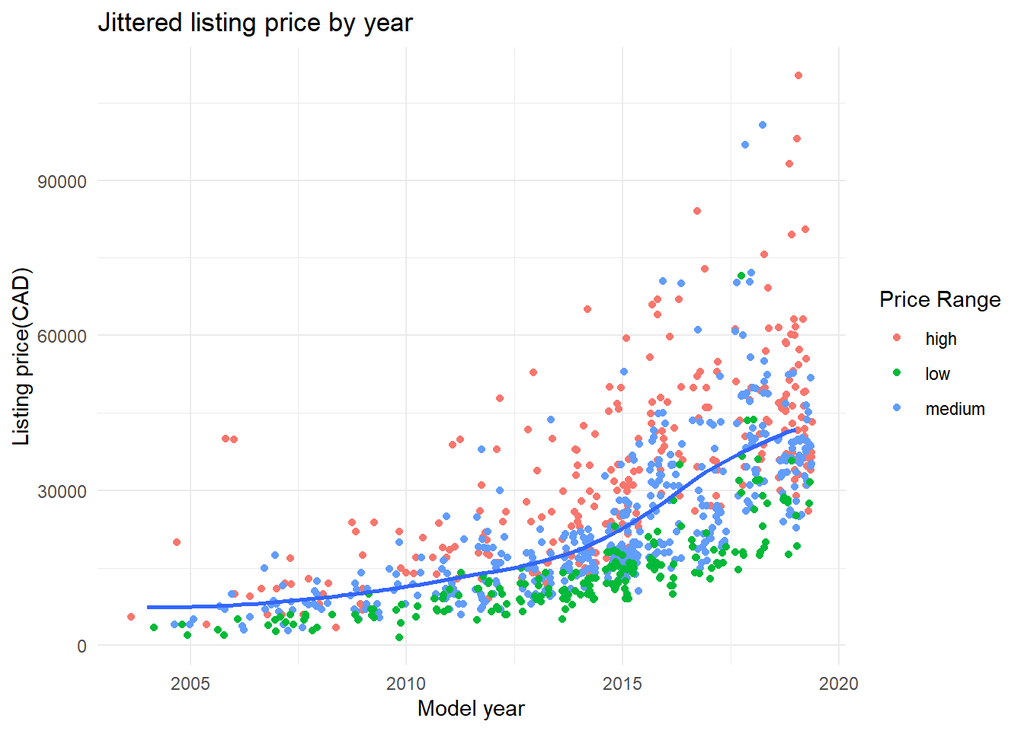

These charts show that the listing prices of cars is typically higher for more recent models.

Separating cars based on their price range, we see that the decrease in price for older cars occurs at a higher rate for cars among the top 25th percentile of prices every year, compared to less relatively expensive cars. This supports the idea that the price decay is based on the starting price of the car.

The curve of the line suggests that the decay may be exponential, although there are other viable explanations and this observation may be biased by prior knowledge.

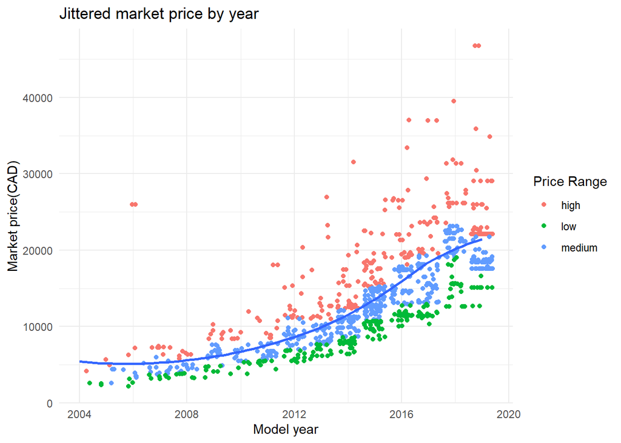

This plot of market price by model year corroborates previous findings and shows a more well-defined curve of prices over time. Note that price range was defined based on quantiles of market price per year, which is why the points are perfectly stacked on top of each other by color.

We see that the green, “low price range,” points, are close together and market price seems strongly associated with model year, whereas among the “high price range” points, the points form a cone shape, indicating there is more variability among prices over the years.

This supports the hypothesis that the decay schedule is exponential, thus cars initially worth more observe larger decreases in price over time compared to cars worth less.

In addition, lower-cost vehicles may have a higher lifespan and lower maintenance costs compared to expensive luxury vehicles. Thus, luxury vehicles may decrease in price faster because of the shorter lifespan.

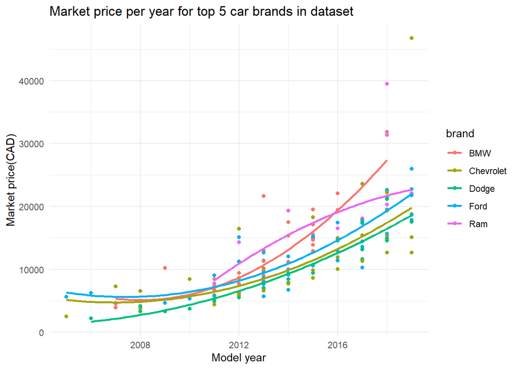

We can roughly inspect the changes in price over the year for cars of different brands. Note that observations for a single brand may include different types of cars(sedans, SUVs) that have different price points, influencing the fitted line.

However, the line shows that brand can be a useful predictor of depreciation. For example, BMW cars rank relatively low in terms of maintenance costs, and are quite expensive to own. This fact may be reflected in the fact that the fitted line for BMWs has a much higher slope that some of the other cars, such as Dodge, Ford and RAM. Since different manufacturers have varying approaches to making vehicles, and probably have common features and problems with their vehicles, there may be an interaction between other variables such as mileage and body type, with brand.

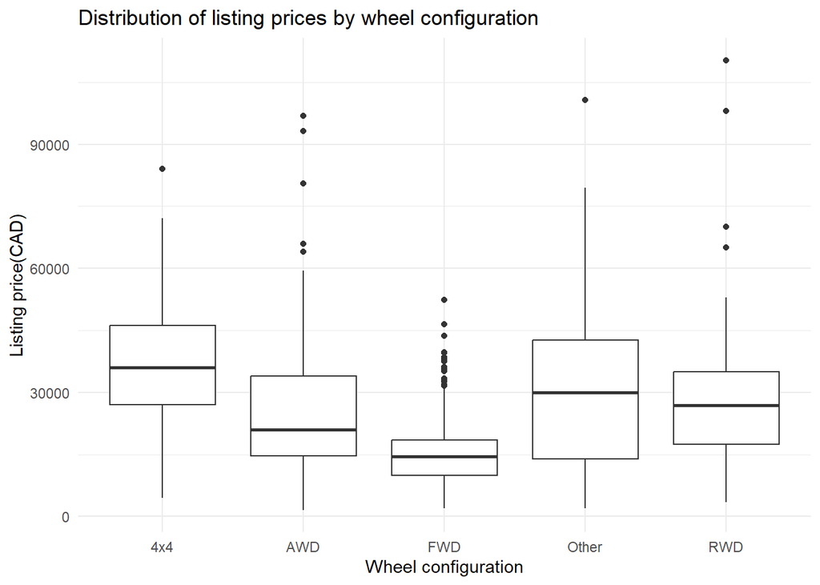

This plot suggests that wheel configuration may be significantly associated with listing prices.

The chart suggests that front wheel drive(FWD) cars typically have low listing prices, whereas other cars such as rear and all wheel drive cars, tend to have higher prices. 4x4 cars seem to have the highest median listing prices among all categories.

However, this may be because rear wheel drive cars tend to be sports cars, which are more expensive, and AWD/4x4 cars tend to be SUVs or vans, which are more expensive than cars, which make up most of front wheel drive vehicles. Thus, the type of vehicle may be confounding the results.

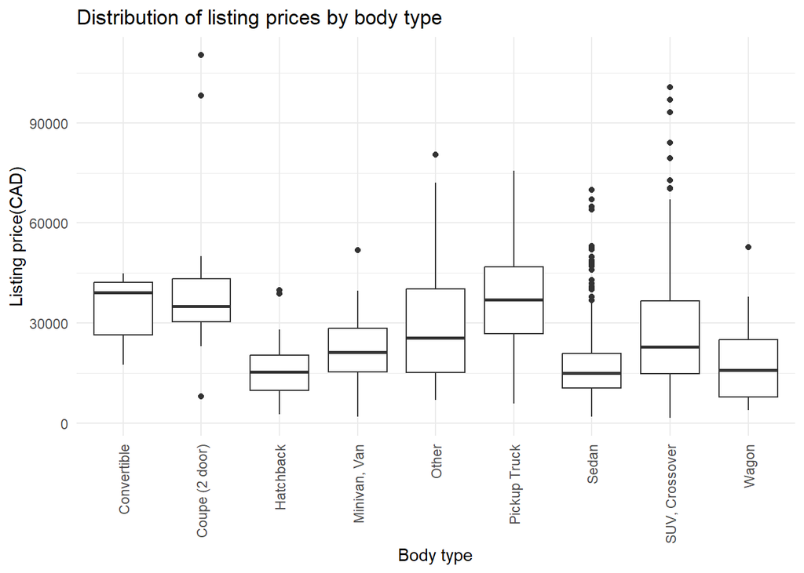

We see a similar result for different body types, supporting the previous conclusion. convertibles, coupes and pickup trucks have the highest median listing price among all body types, whereas sedans and hatchbacks have the lowest median listing prices.

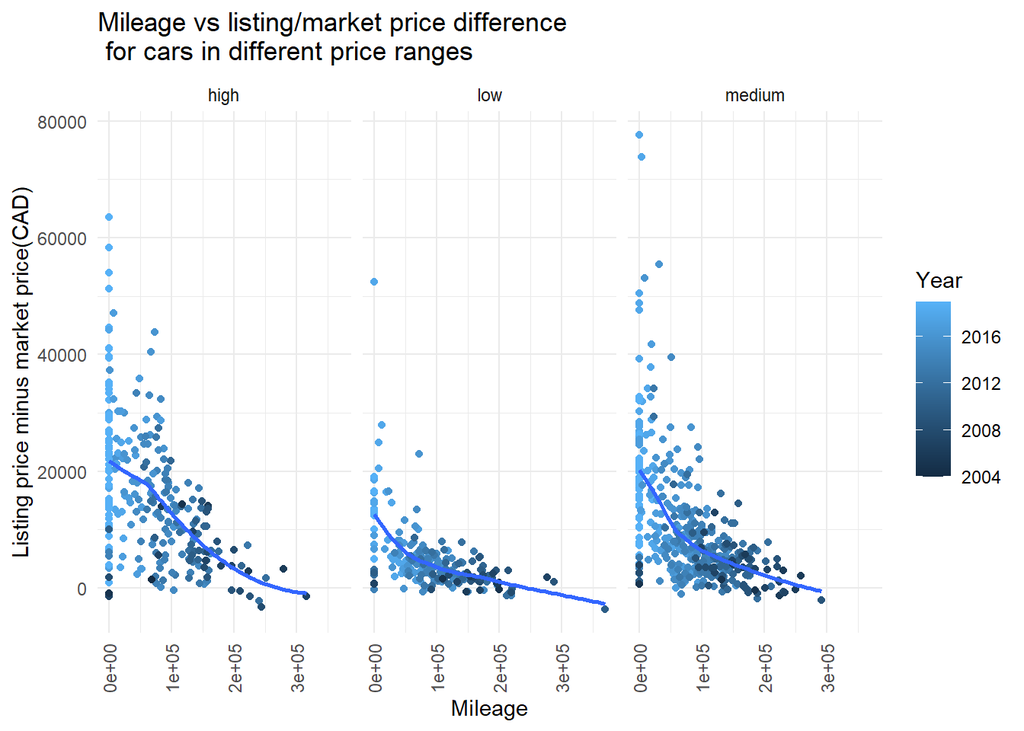

It’s common knowledge that higher mileage is associated with lower prices in used cars. Thus, I decided to plot the effect of mileage on the difference between the listing price of a used car with its market price.

We see that higher mileage is associated with lower listing prices, when compared to the market price of a car. We see a low spread of prices among cars in the “low” price range, and a higher spread among the other price ranges.

These plots are similar to the previous plots, suggesting that the decay in price associated with higher mileage is proportional to the initial price of each vehicle.

However, we see that year seems highly correlated with mileage, by the color of the points, suggesting multicollinearity and confounding may be an issue in the investigation.

However, we see a few observations for older models, that have low prices despite having low mileage. This suggests that the year of the car model is still influential of the market/listing price, regardless of mileage.

# Summary

So far, I’ve found a lot of evidence supporting the hypothesis that the listing and market prices of used cars are highly correlated, and that they decay at an exponential rate based on other factors such as the year a car was made(compared to the current year), and the mileage of a car.

I’ve also found evidence that attributes such as car type and wheel configuration are associated with listing prices. For example, all and rear wheel drive vehicles usually have higher listing prices compared to front wheel drive vehicles.

However, multicollinearity and confounding is a large issue in the data. For example, model year is associated with mileage. In addition, wheel configuration is associated with body type.

The next step is to find a way to investigate the central question in a way that would be meaningful to a dealership or prospective buyer. Currently, I have only found evidence in supporting prior knowledge, and I aim to quantify my findings and search for useful insights in the data in the rest of the project.